# Homework 1

Author: Matthew J. Cossley

Last update: 17 February, 2021

### 0. Study

- [Programming basics](https://rstudio.cloud/learn/primers/1.2)
- [Data Table](https://cran.r-project.org/web/packages/data.table/vignettes/datatable-intro.html)
- [Bar charts](https://rstudio.cloud/learn/primers/3.2)
- [Histograms](https://rstudio.cloud/learn/primers/3.3)
- [Box plots and counts](https://rstudio.cloud/learn/primers/3.4)
- [Scatter plots](https://rstudio.cloud/learn/primers/3.6)

### 1. criterion learning experiment

Does feedback-delay impair criterion learning? What is criterion learning? Here is an example trial:

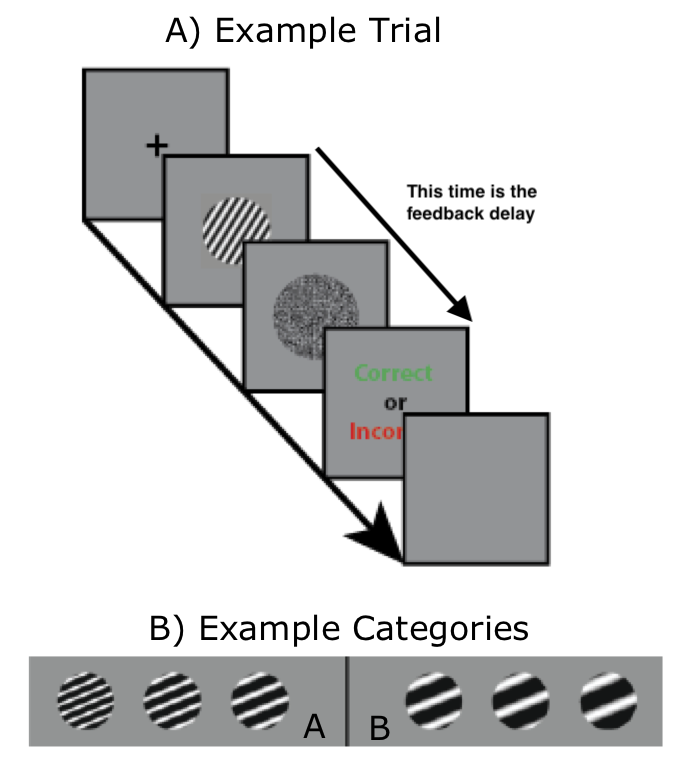

In this case, thin bars belong to category A, and thick bars belong to category B. But where exactly is the category boundary (i.e., criterion) that separates thick from thin? Criterion learning is the process that allows our brains to figure this out. Next, you will perform a cursory analysis on the data from this experiment.

1. Read `https://crossley.github.io/cogs2020/data/criterion_learning/crit_learn.csv` into a `data.table` and store the result in a variable named `ans_1a`.
2. Select only rows for which `cnd == Delay` or for which `cnd == Long ITI` and store the result in a variable named `ans_1b`.
3. Create a new `data.table` that contains only a `cnd`, `sub` and mean `t2c` per `cnd` per `sub`, and store the result in a variable named `ans_1c`.
   - Make sure that your resulting `data.table` has correctly named columns (i.e., any columns named `V1` etc. will lead to this question being marked incorrect).
   - Also make sure that your resulting `data.frame` only has one observation per subject. Failure to do so will lead to this question being marked incorrect.
4. Use `ggplot` to reproduce the following plot exactly and store the resulting `ggplot` object in a variable named `ans_1d`.

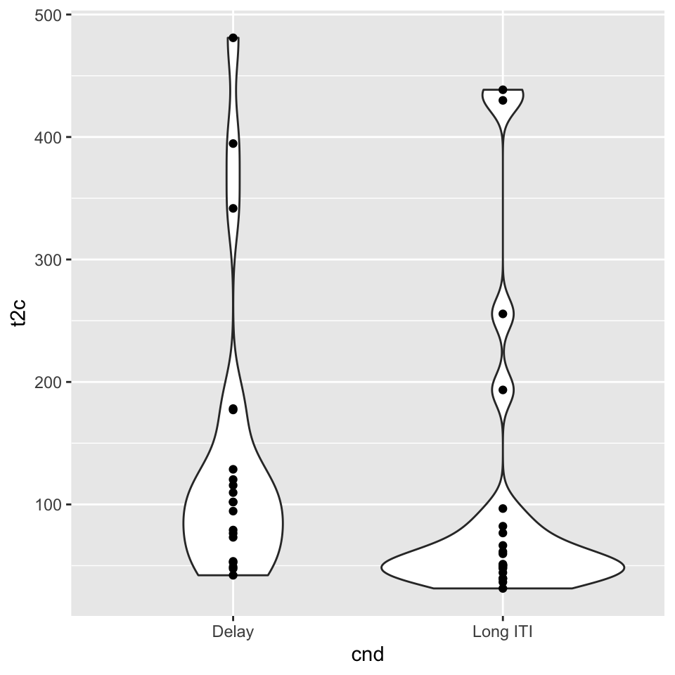

5. Use `ggplot` to reproduce the following plot exactly and store the resulting `ggplot` object in a variable named `ans_1d`.

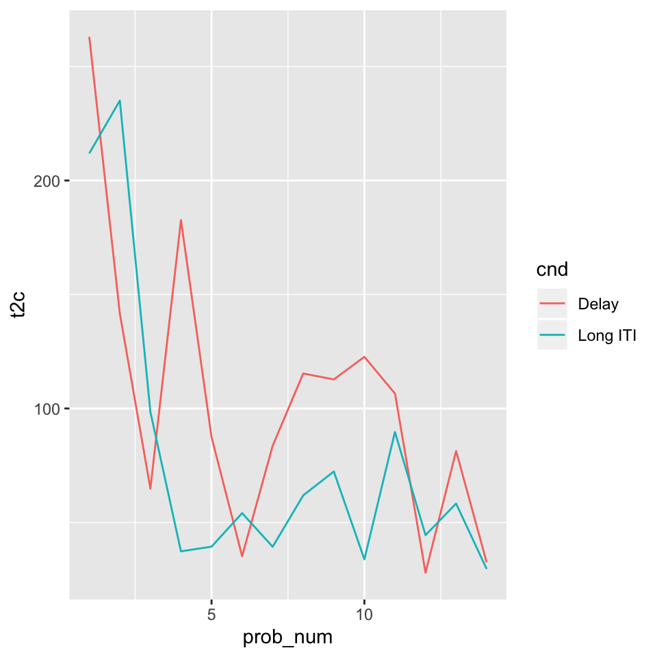

### 2. Rat maze experiment

Consider an experiment in which a set of rats run through a set of mazes some number of times each. The researchers running this experiment are interested in how quickly rats can run these mazes, and so they record the `time` in seconds each `rat` takes to complete each `run` of each `maze`. Next, you will perform a cursory analysis on the data from this experiment.

1. Read ‘https://crossley.github.io/cogs2020/data/maze/maze.csv’ into a `data.table` and store the result in a variable named `ans_2a`.
2. `rat` and `maze` are both *categorical* experimental factors. All this means is that rat 2 cannot be said to be greater than rat 1 in any meaningful sense. However, they are currently coded as integers in the `data.table`. Change the coding of `rat` and `maze` to `factor` and store the result in a variable named `ans_2b`.
3. Turns out that something was wrong with maze 1, so we can’t include it in our analysis. Select all rows except those corresponding to `maze == 1` and store the result in a variable named `ans_2c`.
4. Create a new `data.table` that contains only a `maze`, `rat` and mean `time` per `maze` per `rat`, and store the result in a variable named `ans_2d`.
   - Make sure that your resulting `data.table` has correctly named columns (i.e., any columns named `V1` etc. will lead to this question being marked incorrect).
   - Also make sure that your resulting `data.frame` only has one observation per rat per maze. Failure to do so will lead to this question being marked incorrect.
5. Use `ggplot` to reproduce the following plot exactly and store the resulting `ggplot` object in a variable named `ans_2e`.

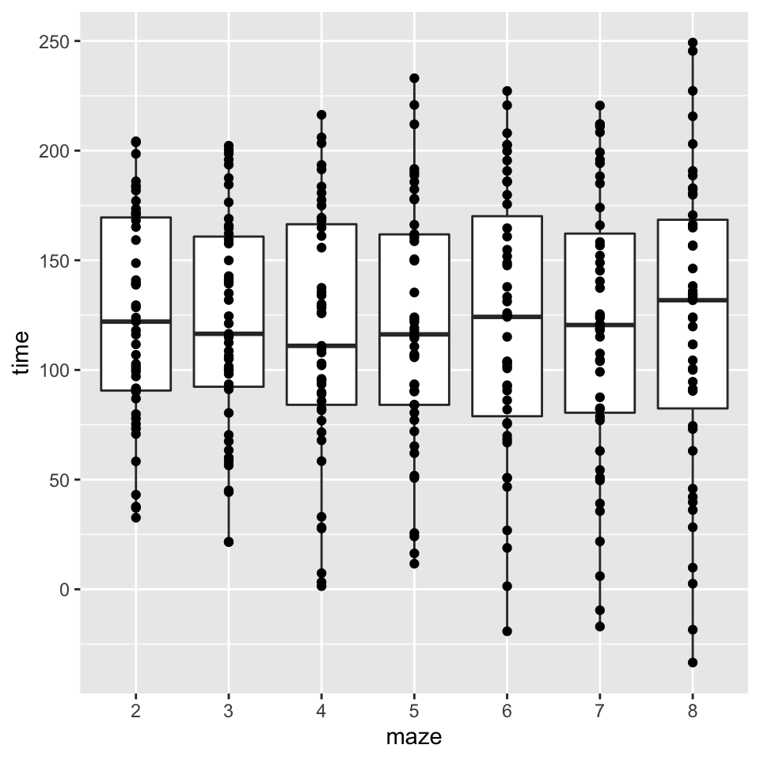